# Predict Bike Sharing Demand with AutoGluon Template

### Download and explore dataset

### Go to the bike sharing demand competition and agree to the terms

```python
# # Download the dataset, it will be in a .zip file so you'll need to unzip it as well.
!kaggle competitions download -c bike-sharing-demand
# # If you already downloaded it you can use the -o command to overwrite the file
!unzip -o bike-sharing-demand.zip
```

```
bike-sharing-demand.zip: Skipping, found more recently modified local copy (use --force to force download)
Archive:  bike-sharing-demand.zip
  inflating: sampleSubmission.csv
  inflating: test.csv
  inflating: train.csv
```

```python
import pandas as pd
from autogluon.tabular import TabularPredictor
```

```python
# Create the train dataset in pandas by reading the csv
# Set the parsing of the datetime column so you can use some of the `dt` features in pandas later
import pandas as pd
train = pd.read_csv(
    "train.csv",
    parse_dates=["datetime"],
    date_parser=lambda x: pd.to_datetime(x, format="%Y-%m-%d %H:%M:%S"),
)
train.head()
```

|  | datetime | season | holiday | workingday | weather | temp | atemp | humidity | windspeed | casual | registered | count |
| --- | --- | --- | --- | --- | --- | --- | --- | --- | --- | --- | --- | --- |
| 0 | 2011-01-01 00:00:00 | 1 | 0 | 0 | 1 | 9.84 | 14.395 | 81 | 0.0 | 3 | 13 | 16 |
| 1 | 2011-01-01 01:00:00 | 1 | 0 | 0 | 1 | 9.02 | 13.635 | 80 | 0.0 | 8 | 32 | 40 |
| 2 | 2011-01-01 02:00:00 | 1 | 0 | 0 | 1 | 9.02 | 13.635 | 80 | 0.0 | 5 | 27 | 32 |
| 3 | 2011-01-01 03:00:00 | 1 | 0 | 0 | 1 | 9.84 | 14.395 | 75 | 0.0 | 3 | 10 | 13 |
| 4 | 2011-01-01 04:00:00 | 1 | 0 | 0 | 1 | 9.84 | 14.395 | 75 | 0.0 | 0 | 1 | 1 |

```python
# Simple output of the train dataset to view some of the min/max/varition of the dataset features.
train.describe().T
```

|  | count | mean | min | 25% | 50% | 75% | max | std |
| --- | --- | --- | --- | --- | --- | --- | --- | --- |
| datetime | 10886 | 2011-12-27 05:56:22.399411968 | 2011-01-01 00:00:00 | 2011-07-02 07:15:00 | 2012-01-01 20:30:00 | 2012-07-01 12:45:00 | 2012-12-19 23:00:00 | NaN |
| season | 10886.0 | 2.506614 | 1.0 | 2.0 | 3.0 | 4.0 | 4.0 | 1.116174 |
| holiday | 10886.0 | 0.028569 | 0.0 | 0.0 | 0.0 | 0.0 | 1.0 | 0.166599 |
| workingday | 10886.0 | 0.680875 | 0.0 | 0.0 | 1.0 | 1.0 | 1.0 | 0.466159 |
| weather | 10886.0 | 1.418427 | 1.0 | 1.0 | 1.0 | 2.0 | 4.0 | 0.633839 |
| temp | 10886.0 | 20.23086 | 0.82 | 13.94 | 20.5 | 26.24 | 41.0 | 7.79159 |
| atemp | 10886.0 | 23.655084 | 0.76 | 16.665 | 24.24 | 31.06 | 45.455 | 8.474601 |
| humidity | 10886.0 | 61.88646 | 0.0 | 47.0 | 62.0 | 77.0 | 100.0 | 19.245033 |
| windspeed | 10886.0 | 12.799395 | 0.0 | 7.0015 | 12.998 | 16.9979 | 56.9969 | 8.164537 |
| casual | 10886.0 | 36.021955 | 0.0 | 4.0 | 17.0 | 49.0 | 367.0 | 49.960477 |
| registered | 10886.0 | 155.552177 | 0.0 | 36.0 | 118.0 | 222.0 | 886.0 | 151.039033 |
| count | 10886.0 | 191.574132 | 1.0 | 42.0 | 145.0 | 284.0 | 977.0 | 181.144454 |

```python
train.info()
```

```
<class 'pandas.core.frame.DataFrame'>
RangeIndex: 10886 entries, 0 to 10885
Data columns (total 12 columns):
 #   Column      Non-Null Count  Dtype
---  ------      --------------  -----
 0   datetime    10886 non-null  datetime64[ns]
 1   season      10886 non-null  int64
 2   holiday     10886 non-null  int64
 3   workingday  10886 non-null  int64
 4   weather     10886 non-null  int64
 5   temp        10886 non-null  float64
 6   atemp       10886 non-null  float64
 7   humidity    10886 non-null  int64
 8   windspeed   10886 non-null  float64
 9   casual      10886 non-null  int64
 10  registered  10886 non-null  int64
 11  count       10886 non-null  int64
dtypes: datetime64[ns](1), float64(3), int64(8)
memory usage: 1020.7 KB
```

```python
# Create the test pandas dataframe in pandas by reading the csv, remember to parse the datetime!
test = pd.read_csv(
    "test.csv",
    parse_dates=["datetime"],
    date_parser=lambda x: pd.to_datetime(x, format="%Y-%m-%d %H:%M:%S"),
)
test.head()
```

|  | datetime | season | holiday | workingday | weather | temp | atemp | humidity | windspeed |
| --- | --- | --- | --- | --- | --- | --- | --- | --- | --- |
| 0 | 2011-01-20 00:00:00 | 1 | 0 | 1 | 1 | 10.66 | 11.365 | 56 | 26.0027 |
| 1 | 2011-01-20 01:00:00 | 1 | 0 | 1 | 1 | 10.66 | 13.635 | 56 | 0.0000 |
| 2 | 2011-01-20 02:00:00 | 1 | 0 | 1 | 1 | 10.66 | 13.635 | 56 | 0.0000 |
| 3 | 2011-01-20 03:00:00 | 1 | 0 | 1 | 1 | 10.66 | 12.880 | 56 | 11.0014 |
| 4 | 2011-01-20 04:00:00 | 1 | 0 | 1 | 1 | 10.66 | 12.880 | 56 | 11.0014 |

```python
# Same thing as train and test dataset
submission = pd.read_csv(
    "sampleSubmission.csv",
    parse_dates=["datetime"],
    date_parser=lambda x: pd.to_datetime(x, format="%Y-%m-%d %H:%M:%S"),
)
submission.head()
```

|  | datetime | count |
| --- | --- | --- |
| 0 | 2011-01-20 00:00:00 | 0 |
| 1 | 2011-01-20 01:00:00 | 0 |
| 2 | 2011-01-20 02:00:00 | 0 |
| 3 | 2011-01-20 03:00:00 | 0 |
| 4 | 2011-01-20 04:00:00 | 0 |

## Step 3: Train a model using AutoGluon’s Tabular Prediction

Requirements:

- We are prediting `count`, so it is the label we are setting.
- Ignore `casual` and `registered` columns as they are also not present in the test dataset.
- Use the `root_mean_squared_error` as the metric to use for evaluation.
- Set a time limit of 10 minutes (600 seconds).
- Use the preset `best_quality` to focus on creating the best model.

```python
train.columns
```

```
Index(['datetime', 'season', 'holiday', 'workingday', 'weather', 'temp',
       'atemp', 'humidity', 'windspeed', 'casual', 'registered', 'count'],
      dtype='object')
```

```python
df_train = train.copy()
```

```python
df_train = df_train.drop(columns=["casual", "registered"])  # Drop the target columns
```

```python
df_train.columns
```

```
Index(['datetime', 'season', 'holiday', 'workingday', 'weather', 'temp',
       'atemp', 'humidity', 'windspeed', 'count'],
      dtype='object')
```

```python
from autogluon.tabular import TabularPredictor
# Specify the label column for the predictor
predictor = TabularPredictor(label="count",problem_type="regression",
                             eval_metric="root_mean_squared_error").fit(train_data=df_train, time_limit=600,presets="best_quality")
```

[output not shown]

[output cut: 34 more lines]

[output not shown]

[output not shown]

[output not shown]

[output not shown]

[output not shown]

[output cut: 19 more lines]

[output not shown]

```
(_ray_fit pid=51734) [1000]	valid_set's rmse: 73.9398 [repeated 7x across cluster]
```

[output not shown]

[output cut: 239 more lines]

[output not shown]

### Review AutoGluon's training run with ranking of models that did the best.

```python
# ! pip install bokeh
```

```python
predictor.fit_summary()
```

```
*** Summary of fit() ***
Estimated performance of each model:
                          model   score_val              eval_metric  pred_time_val    fit_time  pred_time_val_marginal  fit_time_marginal  stack_level  can_infer  fit_order
0           WeightedEnsemble_L3  -49.663678  root_mean_squared_error       7.845178  373.536702                0.000364           0.100469            3       True         30
1     NeuralNetTorch_r79_BAG_L2  -50.987939  root_mean_squared_error       7.097517  326.164293                0.104428          49.977686            2       True         27
2        NeuralNetFastAI_BAG_L2  -52.287290  root_mean_squared_error       7.076206  281.280556                0.083117           5.093949            2       True         22
3        RandomForestMSE_BAG_L2  -53.486951  root_mean_squared_error       7.289988  280.565206                0.296899           4.378599            2       True         19
4          ExtraTreesMSE_BAG_L2  -54.438312  root_mean_squared_error       7.276632  277.289521                0.283543           1.102914            2       True         21
5         NeuralNetTorch_BAG_L2  -54.849078  root_mean_squared_error       7.076828  312.883085                0.083739          36.696478            2       True         24
6          LightGBMLarge_BAG_L2  -54.974856  root_mean_squared_error       7.265350  278.208800                0.272261           2.022193            2       True         25
7               LightGBM_BAG_L2  -55.114909  root_mean_squared_error       7.153875  277.327077                0.160786           1.140470            2       True         18
8                XGBoost_BAG_L2  -55.309874  root_mean_squared_error       7.035766  277.942986                0.042677           1.756379            2       True         23
9          LightGBM_r131_BAG_L2  -55.475960  root_mean_squared_error       8.630366  279.250085                1.637277           3.063478            2       True         28
10         CatBoost_r177_BAG_L2  -56.014486  root_mean_squared_error       7.002737  284.428689                0.009648           8.242082            2       True         26
11              CatBoost_BAG_L2  -56.120225  root_mean_squared_error       7.003024  285.400537                0.009935           9.213930            2       True         20
12            LightGBMXT_BAG_L2  -60.498213  root_mean_squared_error       8.508441  279.092712                1.515352           2.906105            2       True         17
13  NeuralNetFastAI_r191_BAG_L2  -60.908246  root_mean_squared_error       7.155594  281.752408                0.162505           5.565801            2       True         29
14        KNeighborsDist_BAG_L1  -84.146423  root_mean_squared_error       0.012439    0.005897                0.012439           0.005897            1       True          2
15          WeightedEnsemble_L2  -84.146423  root_mean_squared_error       0.012870    0.068203                0.000431           0.062306            2       True         16
16        KNeighborsUnif_BAG_L1 -101.588176  root_mean_squared_error       0.015341    0.007084                0.015341           0.007084            1       True          1
17       RandomForestMSE_BAG_L1 -116.542032  root_mean_squared_error       0.262256    1.179904                0.262256           1.179904            1       True          5
18         ExtraTreesMSE_BAG_L1 -124.577581  root_mean_squared_error       0.241873    0.515021                0.241873           0.515021            1       True          7
19         LightGBM_r131_BAG_L1 -129.862938  root_mean_squared_error       2.280775    2.869075                2.280775           2.869075            1       True         14
20         LightGBMLarge_BAG_L1 -130.035209  root_mean_squared_error       0.330536    1.141362                0.330536           1.141362            1       True         11
21              CatBoost_BAG_L1 -130.504020  root_mean_squared_error       0.019145   30.935920                0.019145          30.935920            1       True          6
22         CatBoost_r177_BAG_L1 -130.613472  root_mean_squared_error       0.042326   22.218436                0.042326          22.218436            1       True         12
23              LightGBM_BAG_L1 -131.054162  root_mean_squared_error       0.559464    1.307778                0.559464           1.307778            1       True          4
24            LightGBMXT_BAG_L1 -131.460909  root_mean_squared_error       2.627570    3.224399                2.627570           3.224399            1       True          3
25               XGBoost_BAG_L1 -131.893935  root_mean_squared_error       0.132389    0.932710                0.132389           0.932710            1       True          9
26    NeuralNetTorch_r79_BAG_L1 -134.258956  root_mean_squared_error       0.099487   72.181548                0.099487          72.181548            1       True         13
```

[output cut: 16 more lines]

[output not shown]

[output cut: 439 more lines]

[output not shown]

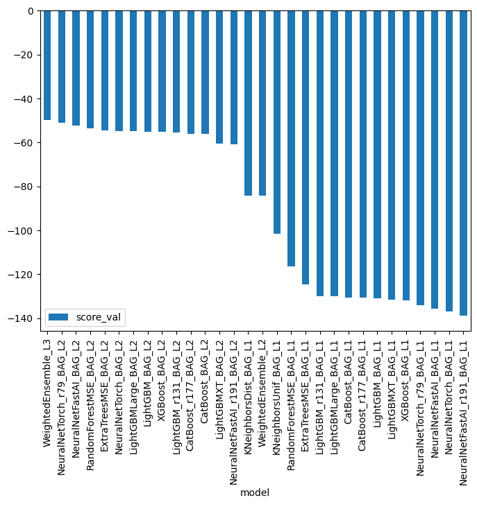

```python
predictor.leaderboard(silent=True).plot(kind="bar", x="model", y="score_val", figsize=(8, 6))
```

### Create predictions from test dataset

```python
# Make predictions on the test dataset

predictions = predictor.predict(test)

predictions.head()
```

```
0    25.121151
1    39.271709
2    44.680058
3    49.304348
4    51.484028
Name: count, dtype: float32
```

#### NOTE: Kaggle will reject the submission if we don't set everything to be > 0.

```python
# Describe the `predictions` series to see if there are any negative values
predictions.describe().T
# Replace negative values with 0
# predictions = predictions.clip(lower=0)
```

```
count    6493.000000
mean       98.328903
std        89.741653
min         3.585035
25%        17.363598
50%        60.317600
75%       171.354965
max       349.031006
Name: count, dtype: float64
```

```python
# How many negative values do we have?
num_negative = (predictions < 0).sum()
print(f"Number of negative predictions: {num_negative}")
```

```
Number of negative predictions: 0
```

```python
# Set them to zero
predictions = predictions.clip(lower=0)
```

### Set predictions to submission dataframe, save, and submit

```python
submission["count"] = predictions
# Save the submission file
submission.to_csv("submission.csv", index=False)
```

```python
!kaggle competitions submit -c bike-sharing-demand -f submission.csv -m "first raw submission"
```

```
Successfully submitted to Bike Sharing Demand
```

#### View submission via the command line or in the web browser under the competition's page - `My Submissions`

```python
!kaggle competitions submissions -c bike-sharing-demand | tail -n +1 | head -n 6
```

```
fileName                     date                        description                        status                     publicScore  privateScore
---------------------------  --------------------------  ---------------------------------  -------------------------  -----------  ------------
submission.csv               2025-05-31 15:45:09.733000  first raw submission               SubmissionStatus.COMPLETE  1.84630      1.84630
submission_new_hpo.csv       2025-05-31 15:32:00.167000  new features with hyperparameters  SubmissionStatus.COMPLETE  0.64745      0.64745
submission_new_features.csv  2025-05-31 15:08:53.570000  new features                       SubmissionStatus.COMPLETE  0.91067      0.91067
submission.csv               2025-05-31 14:58:32.767000  first raw submission               SubmissionStatus.COMPLETE  1.84824      1.84824
```

## Step 4: Exploratory Data Analysis and Creating an additional feature

- Any additional feature will do, but a great suggestion would be to separate out the datetime into hour, day, or month parts.

```
array([[<Axes: title={'center': 'datetime'}>,
        <Axes: title={'center': 'season'}>,
        <Axes: title={'center': 'holiday'}>],
       [<Axes: title={'center': 'workingday'}>,
        <Axes: title={'center': 'weather'}>,
        <Axes: title={'center': 'temp'}>],
       [<Axes: title={'center': 'atemp'}>,
        <Axes: title={'center': 'humidity'}>,
        <Axes: title={'center': 'windspeed'}>],
       [<Axes: title={'center': 'count'}>, <Axes: >, <Axes: >]],
      dtype=object)
```

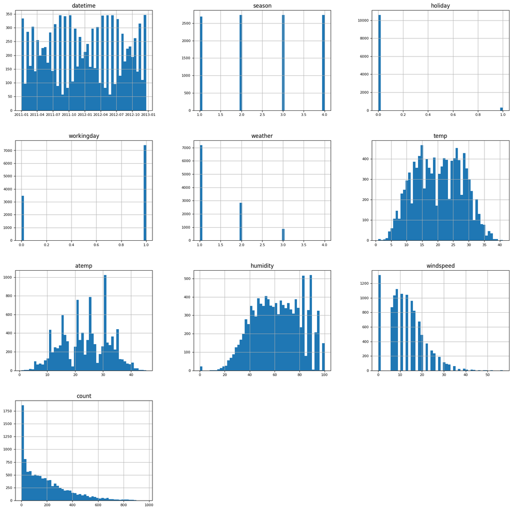

```python
# Create a histogram of all features to show the distribution of each one relative to the data. This is part of the exploritory data analysis
df_train.hist(figsize=(20, 20), bins=50, xlabelsize=8, ylabelsize=8)
```

```python
df_test = test.copy()
df_test.head()
```

|  | datetime | season | holiday | workingday | weather | temp | atemp | humidity | windspeed |
| --- | --- | --- | --- | --- | --- | --- | --- | --- | --- |
| 0 | 2011-01-20 00:00:00 | 1 | 0 | 1 | 1 | 10.66 | 11.365 | 56 | 26.0027 |
| 1 | 2011-01-20 01:00:00 | 1 | 0 | 1 | 1 | 10.66 | 13.635 | 56 | 0.0000 |
| 2 | 2011-01-20 02:00:00 | 1 | 0 | 1 | 1 | 10.66 | 13.635 | 56 | 0.0000 |
| 3 | 2011-01-20 03:00:00 | 1 | 0 | 1 | 1 | 10.66 | 12.880 | 56 | 11.0014 |
| 4 | 2011-01-20 04:00:00 | 1 | 0 | 1 | 1 | 10.66 | 12.880 | 56 | 11.0014 |

```python
# create a new feature
# train[?] = ?
df_train["year"] = df_train["datetime"].dt.year
df_train["month"] = df_train["datetime"].dt.month
df_train["day"] = df_train["datetime"].dt.day
df_train["hour"] = df_train["datetime"].dt.hour
# test[?] = ?
df_test["year"] = df_test["datetime"].dt.year
df_test["month"] = df_test["datetime"].dt.month
df_test["day"] = df_test["datetime"].dt.day
df_test["hour"] = df_test["datetime"].dt.hour
```

```python
df_train.shape
```

```
(10886, 14)
```

```python
df_test.shape
```

```
(6493, 13)
```

```python
df_train.columns
```

```
Index(['datetime', 'season', 'holiday', 'workingday', 'weather', 'temp',
       'atemp', 'humidity', 'windspeed', 'count', 'year', 'month', 'day',
       'hour'],
      dtype='object')
```

```python
df_test.columns
```

```
Index(['datetime', 'season', 'holiday', 'workingday', 'weather', 'temp',
       'atemp', 'humidity', 'windspeed', 'year', 'month', 'day', 'hour'],
      dtype='object')
```

## Make category types for these so models know they are not just numbers

- AutoGluon originally sees these as ints, but in reality they are int representations of a category.
- Setting the dtype to category will classify these as categories in AutoGluon.

```python
df_train.dtypes
```

```
datetime      datetime64[ns]
season                 int64
holiday                int64
workingday             int64
weather                int64
temp                 float64
atemp                float64
humidity               int64
windspeed            float64
count                  int64
year                   int32
month                  int32
day                    int32
hour                   int32
dtype: object
```

```python
df_test.dtypes
```

```
datetime      datetime64[ns]
season                 int64
holiday                int64
workingday             int64
weather                int64
temp                 float64
atemp                float64
humidity               int64
windspeed            float64
year                   int32
month                  int32
day                    int32
hour                   int32
dtype: object
```

```python
#train
df_train["season"] = df_train["season"].astype("category")
df_train["weather"] = df_train["weather"].astype("category")
#test
df_test["season"] = df_test["season"].astype("category")
df_test["weather"] = df_test["weather"].astype("category")
```

```python
df_train.dtypes
```

```
datetime      datetime64[ns]
season              category
holiday                int64
workingday             int64
weather             category
temp                 float64
atemp                float64
humidity               int64
windspeed            float64
count                  int64
year                   int32
month                  int32
day                    int32
hour                   int32
dtype: object
```

```python
df_test.dtypes
```

```
datetime      datetime64[ns]
season              category
holiday                int64
workingday             int64
weather             category
temp                 float64
atemp                float64
humidity               int64
windspeed            float64
year                   int32
month                  int32
day                    int32
hour                   int32
dtype: object
```

```python
# View are new feature
df_train.head()
```

|  | datetime | season | holiday | workingday | weather | temp | atemp | humidity | windspeed | count | year | month | day | hour |
| --- | --- | --- | --- | --- | --- | --- | --- | --- | --- | --- | --- | --- | --- | --- |
| 0 | 2011-01-01 00:00:00 | 1 | 0 | 0 | 1 | 9.84 | 14.395 | 81 | 0.0 | 16 | 2011 | 1 | 1 | 0 |
| 1 | 2011-01-01 01:00:00 | 1 | 0 | 0 | 1 | 9.02 | 13.635 | 80 | 0.0 | 40 | 2011 | 1 | 1 | 1 |
| 2 | 2011-01-01 02:00:00 | 1 | 0 | 0 | 1 | 9.02 | 13.635 | 80 | 0.0 | 32 | 2011 | 1 | 1 | 2 |
| 3 | 2011-01-01 03:00:00 | 1 | 0 | 0 | 1 | 9.84 | 14.395 | 75 | 0.0 | 13 | 2011 | 1 | 1 | 3 |
| 4 | 2011-01-01 04:00:00 | 1 | 0 | 0 | 1 | 9.84 | 14.395 | 75 | 0.0 | 1 | 2011 | 1 | 1 | 4 |

```python
# View are new feature
df_test.head()
```

|  | datetime | season | holiday | workingday | weather | temp | atemp | humidity | windspeed | year | month | day | hour |
| --- | --- | --- | --- | --- | --- | --- | --- | --- | --- | --- | --- | --- | --- |
| 0 | 2011-01-20 00:00:00 | 1 | 0 | 1 | 1 | 10.66 | 11.365 | 56 | 26.0027 | 2011 | 1 | 20 | 0 |
| 1 | 2011-01-20 01:00:00 | 1 | 0 | 1 | 1 | 10.66 | 13.635 | 56 | 0.0000 | 2011 | 1 | 20 | 1 |
| 2 | 2011-01-20 02:00:00 | 1 | 0 | 1 | 1 | 10.66 | 13.635 | 56 | 0.0000 | 2011 | 1 | 20 | 2 |
| 3 | 2011-01-20 03:00:00 | 1 | 0 | 1 | 1 | 10.66 | 12.880 | 56 | 11.0014 | 2011 | 1 | 20 | 3 |
| 4 | 2011-01-20 04:00:00 | 1 | 0 | 1 | 1 | 10.66 | 12.880 | 56 | 11.0014 | 2011 | 1 | 20 | 4 |

```
array([[<Axes: title={'center': 'datetime'}>,
        <Axes: title={'center': 'holiday'}>,
        <Axes: title={'center': 'workingday'}>],
       [<Axes: title={'center': 'temp'}>,
        <Axes: title={'center': 'atemp'}>,
        <Axes: title={'center': 'humidity'}>],
       [<Axes: title={'center': 'windspeed'}>,
        <Axes: title={'center': 'count'}>,
        <Axes: title={'center': 'year'}>],
       [<Axes: title={'center': 'month'}>,
        <Axes: title={'center': 'day'}>,
        <Axes: title={'center': 'hour'}>]], dtype=object)
```

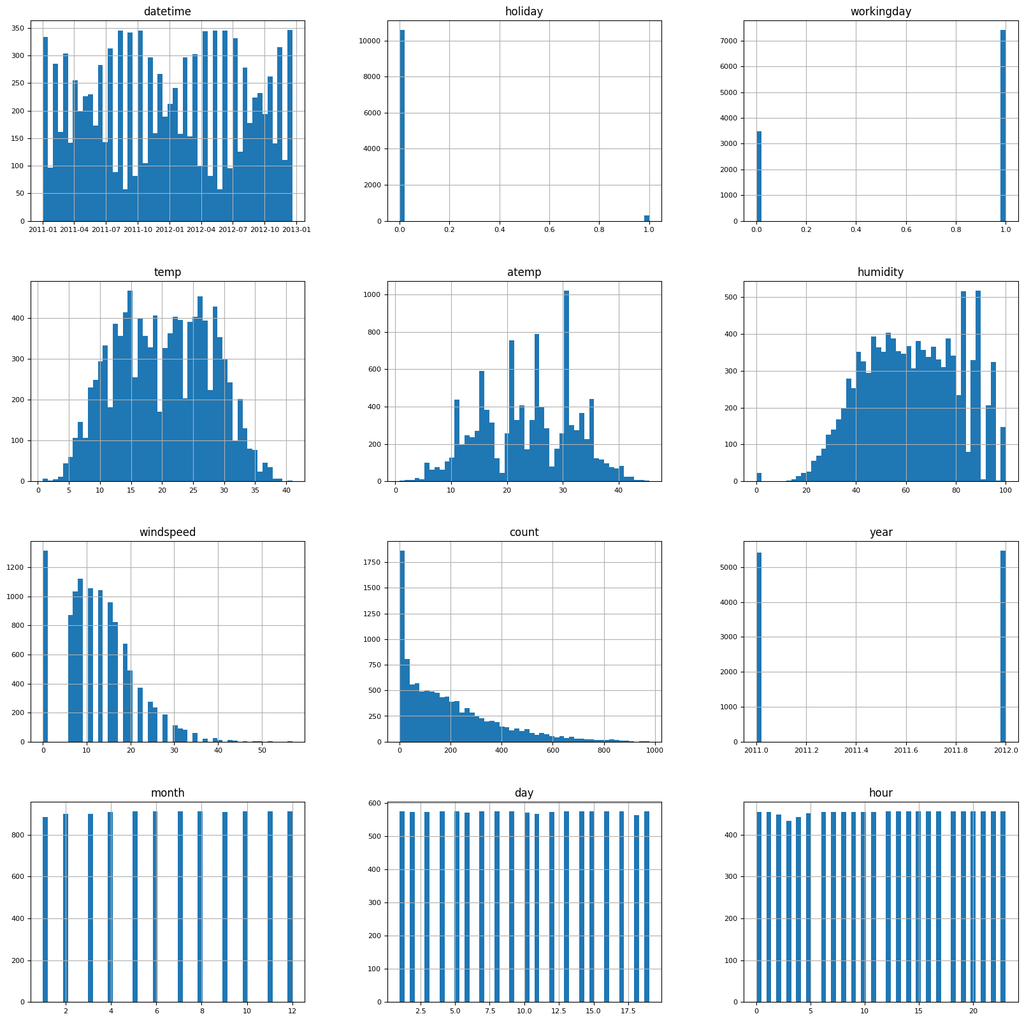

```python
# View histogram of all features again now with the hour feature
df_train.hist(figsize=(20, 20), bins=50, xlabelsize=8, ylabelsize=8)
```

## Step 5: Rerun the model with the same settings as before, just with more features

```python
# Create the predictor again with the new features
predictor_new_features = TabularPredictor(label="count",problem_type="regression",
                             eval_metric="root_mean_squared_error").fit(train_data=df_train, time_limit=600,presets="best_quality")
```

[output not shown]

[output cut: 191 more lines]

[output not shown]

```python
predictor_new_features.fit_summary()
```

```
*** Summary of fit() ***
Estimated performance of each model:
                          model   score_val              eval_metric  pred_time_val    fit_time  pred_time_val_marginal  fit_time_marginal  stack_level  can_infer  fit_order
0           WeightedEnsemble_L3  -27.396531  root_mean_squared_error      20.499863  341.760120                0.000339           0.042627            3       True         29
1     NeuralNetTorch_r79_BAG_L2  -27.547068  root_mean_squared_error      20.028887  332.265092                0.146449          52.211656            2       True         26
2        NeuralNetFastAI_BAG_L2  -29.184928  root_mean_squared_error      19.979529  285.433618                0.097091           5.380182            2       True         21
3               CatBoost_BAG_L2  -30.010721  root_mean_squared_error      19.901439  301.823778                0.019001          21.770342            2       True         19
4               LightGBM_BAG_L2  -30.083439  root_mean_squared_error      20.001197  280.986384                0.118759           0.932948            2       True         17
5          CatBoost_r177_BAG_L2  -30.089873  root_mean_squared_error      19.901442  286.781992                0.019004           6.728556            2       True         25
6          LightGBM_r131_BAG_L2  -30.233136  root_mean_squared_error      20.493496  281.841245                0.611058           1.787809            2       True         27
7                XGBoost_BAG_L2  -30.379630  root_mean_squared_error      19.933793  281.360409                0.051355           1.306973            2       True         22
8          LightGBMLarge_BAG_L2  -30.498050  root_mean_squared_error      20.085869  281.885733                0.203431           1.832297            2       True         24
9             LightGBMXT_BAG_L2  -30.529283  root_mean_squared_error      20.180755  281.151327                0.298317           1.097891            2       True         16
10         ExtraTreesMSE_BAG_L2  -30.803456  root_mean_squared_error      20.181450  281.145531                0.299012           1.092095            2       True         20
11          WeightedEnsemble_L2  -30.905168  root_mean_squared_error      19.026182  170.600761                0.000222           0.015488            2       True         15
12        NeuralNetTorch_BAG_L2  -30.929936  root_mean_squared_error      20.011042  300.198295                0.128604          20.144859            2       True         23
13       RandomForestMSE_BAG_L2  -31.015645  root_mean_squared_error      20.177443  284.803578                0.295005           4.750142            2       True         18
14  NeuralNetFastAI_r191_BAG_L2  -32.376439  root_mean_squared_error      20.010158  286.449147                0.127720           6.395711            2       True         28
15         CatBoost_r177_BAG_L1  -32.960142  root_mean_squared_error       0.044516   36.079992                0.044516          36.079992            1       True         12
16              CatBoost_BAG_L1  -33.165869  root_mean_squared_error       0.089571   68.777774                0.089571          68.777774            1       True          6
17         LightGBM_r131_BAG_L1  -33.239616  root_mean_squared_error      11.726012    5.975252               11.726012           5.975252            1       True         14
18         LightGBMLarge_BAG_L1  -33.887790  root_mean_squared_error       0.830077    3.272230                0.830077           3.272230            1       True         11
19              LightGBM_BAG_L1  -33.917339  root_mean_squared_error       1.091698    2.375454                1.091698           2.375454            1       True          4
20            LightGBMXT_BAG_L1  -34.453884  root_mean_squared_error       4.788431    4.425815                4.788431           4.425815            1       True          3
21               XGBoost_BAG_L1  -34.602917  root_mean_squared_error       0.432228    2.696691                0.432228           2.696691            1       True          9
22        NeuralNetTorch_BAG_L1  -34.713551  root_mean_squared_error       0.096043  115.753483                0.096043         115.753483            1       True         10
23         ExtraTreesMSE_BAG_L1  -38.093149  root_mean_squared_error       0.252841    0.605010                0.252841           0.605010            1       True          7
24       RandomForestMSE_BAG_L1  -38.438105  root_mean_squared_error       0.261025    1.210287                0.261025           1.210287            1       True          5
25       NeuralNetFastAI_BAG_L1  -45.130364  root_mean_squared_error       0.077709    4.954460                0.077709           4.954460            1       True          8
26    NeuralNetTorch_r79_BAG_L1  -46.042914  root_mean_squared_error       0.158320   33.911995                0.158320          33.911995            1       True         13
```

[output cut: 16 more lines]

[output not shown]

[output cut: 423 more lines]

[output not shown]

```python
# Remember to set all negative values to zero
predictions_NF = predictor_new_features.predict(df_test)
predictions_NF = predictions_NF.clip(lower=0)
```

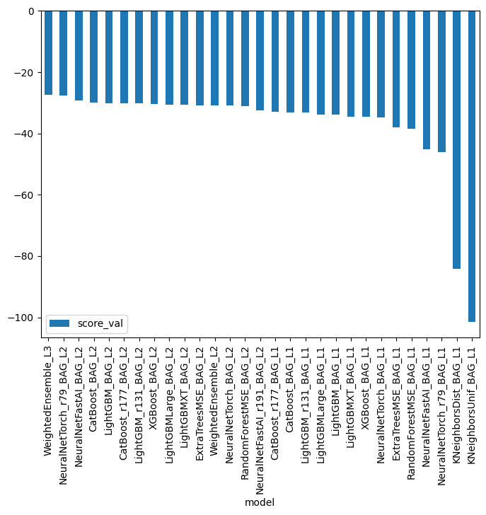

```python
predictor_new_features.leaderboard(silent=True).plot(kind="bar", x="model", y="score_val", figsize=(8, 6))
```

```python
# Same submitting predictions
submission_new_features = submission.copy()
# Make predictions on the test dataset with the new features
submission_new_features["count"] = predictor_new_features.predict(df_test)
submission_new_features.to_csv("submission_new_features.csv", index=False)
```

```python
!kaggle competitions submit -c bike-sharing-demand -f submission_new_features.csv -m "new features"
```

```
Successfully submitted to Bike Sharing Demand
```

```python
!kaggle competitions submissions -c bike-sharing-demand | tail -n +1 | head -n 6
```

```
fileName                     date                        description                        status                     publicScore  privateScore
---------------------------  --------------------------  ---------------------------------  -------------------------  -----------  ------------
submission_new_features.csv  2025-05-31 15:55:41.220000  new features                       SubmissionStatus.COMPLETE  0.91047      0.91047
submission.csv               2025-05-31 15:45:09.733000  first raw submission               SubmissionStatus.COMPLETE  1.84630      1.84630
submission_new_hpo.csv       2025-05-31 15:32:00.167000  new features with hyperparameters  SubmissionStatus.COMPLETE  0.64745      0.64745
submission_new_features.csv  2025-05-31 15:08:53.570000  new features                       SubmissionStatus.COMPLETE  0.91067      0.91067
```

## Step 6: Hyper parameter optimization

- There are many options for hyper parameter optimization.
- Options are to change the AutoGluon higher level parameters or the individual model hyperparameters.
- The hyperparameters of the models themselves that are in AutoGluon. Those need the `hyperparameter` and `hyperparameter_tune_kwargs` arguments.

```python
from autogluon.common import space
from autogluon.tabular import TabularPredictor
```

```python
from autogluon.common import space

hyperparameters = {
    'GBM': {
        'learning_rate': space.Real(0.01,0.3,default=0.1),
        'max_depth': space.Int(3,10,default=6),
    },
    'CAT': {
        'learning_rate': space.Real(0.01,0.3,default=0.1),
        'max_depth': space.Int(3,10,default=6),
    },
    'XGB': {
        'learning_rate': space.Real(0.01,0.3,default=0.1),
        'max_depth': space.Int(3,10,default=6),
    },
    'RF': {}
}

predictor_new_hpo = TabularPredictor(
    label = 'count',
    eval_metric= "root_mean_squared_error"
).fit(
    train_data=df_train,
    presets='best_quality',
    time_limit=600,
    hyperparameter_tune_kwargs={
        'num_trials': 10,  # Enough to explore the space
        'scheduler': 'local',
        'searcher': 'bayesopt',  # Bayesian optimization
        'early_stopping': True,
        'grace_period': 5  # For early stopping
    }

)
```

[output not shown]

[output cut: 2548 more lines]

[output not shown]

```python
predictor_new_hpo.fit_summary()
```

```
*** Summary of fit() ***
Estimated performance of each model:
                           model   score_val              eval_metric  pred_time_val   fit_time  pred_time_val_marginal  fit_time_marginal  stack_level  can_infer  fit_order
0            WeightedEnsemble_L3  -30.422892  root_mean_squared_error       8.916594  84.905826                0.000298           0.025367            3       True        164
1            LightGBM_r15_BAG_L2  -30.874708  root_mean_squared_error       8.412796  70.524207                0.183849           2.488818            2       True        117
2             XGBoost_r95_BAG_L2  -30.905288  root_mean_squared_error       8.287522  70.554152                0.058576           2.518763            2       True        161
3            LightGBM_r94_BAG_L2  -30.932423  root_mean_squared_error       8.536748  70.804364                0.307801           2.768975            2       True        126
4             XGBoost_r89_BAG_L2  -31.023228  root_mean_squared_error       8.282700  70.471638                0.053753           2.436249            2       True        100
5             XGBoost_r22_BAG_L2  -31.053928  root_mean_squared_error       8.292166  70.509853                0.063219           2.474464            2       True        143
6            XGBoost_r194_BAG_L2  -31.079735  root_mean_squared_error       8.256601  70.555422                0.027654           2.520033            2       True        104
7             XGBoost_r49_BAG_L2  -31.189628  root_mean_squared_error       8.306741  70.454435                0.077795           2.419046            2       True        133
8           LightGBM_r131_BAG_L2  -31.249966  root_mean_squared_error       8.400890  70.468671                0.171943           2.433282            2       True         88
9            LightGBM_r96_BAG_L2  -31.272572  root_mean_squared_error       8.494031  70.585711                0.265085           2.550322            2       True         91
10          LightGBM_r130_BAG_L2  -31.274685  root_mean_squared_error       8.353042  70.614172                0.124095           2.578783            2       True        101
11          LightGBM_r135_BAG_L2  -31.309308  root_mean_squared_error       8.427900  70.780779                0.198953           2.745390            2       True        142
```

[output cut: 166 more lines]

[output not shown]

[output cut: 2154 more lines]

[output not shown]

```python
predictions_HPO = predictor_new_hpo.predict(df_test)
predictions_HPO = predictions_HPO.clip(lower=0)
```

[figure not shown]

```python
predictor_new_hpo.leaderboard(silent=True).plot(kind="bar", x="model", y="score_val", figsize=(16, 10))
```

```python
# Same submitting predictions
submission_new_hpo = submission.copy()
submission_new_hpo["count"] = predictor_new_hpo.predict(df_test)
submission_new_hpo.to_csv("submission_new_hpo.csv", index=False)
```

```python
!kaggle competitions submit -c bike-sharing-demand -f submission_new_hpo.csv -m "new features with hyperparameters"
```

```
Successfully submitted to Bike Sharing Demand
```

```python
!kaggle competitions submissions -c bike-sharing-demand | tail -n +1 | head -n 6
```

```
fileName                     date                        description                        status                     publicScore  privateScore
---------------------------  --------------------------  ---------------------------------  -------------------------  -----------  ------------
submission_new_hpo.csv       2025-05-31 16:07:59.143000  new features with hyperparameters  SubmissionStatus.COMPLETE  0.62657      0.62657
submission_new_features.csv  2025-05-31 15:55:41.220000  new features                       SubmissionStatus.COMPLETE  0.91047      0.91047
submission.csv               2025-05-31 15:45:09.733000  first raw submission               SubmissionStatus.COMPLETE  1.84630      1.84630
submission_new_hpo.csv       2025-05-31 15:32:00.167000  new features with hyperparameters  SubmissionStatus.COMPLETE  0.64745      0.64745
```